# Relatório

| Bruno Carvalho Logerfo | 151023336 |
| --- | --- |
| Gustavo Hildebrand Batista | 151024693 |
| João Victor Fayad Andreotti | 151023115 |
| Lucas Fernandes Nogueira | 151022658 |
| Pedro Guilherme Somenci Silva | 151024464 |

[output not shown]

## Introdução

Com o surgimento da Internet na década de 90, a comunicação e troca de informações à distância entre pessoas se tornou muito mais simples e prática, e não demorou muito para que essa tecnologia fosse complementada pelas Redes Sociais. Estas ferramentas tornaram-se populares principalmente entre os jovens, por razões como a novidade que as mesmas representam e a maior facilidade de interação entre os mais jovens. Atualmente o uso de redes sociais é algo grandemente comum na sociedade e existem diversos tipos e finalidades para as anteriores, dentre as mais famosas podemos citar: Facebook, YouTube, Twitter e WhatsApp.

Com base numa análise feita através de um questionário entregue respondido por discentes, neste relatório buscamos responder a seguinte pergunta:

**Quais são as influências das mídias sociais sobre discentes da instituição de nível superior UNESP-Bauru-SP?**

## Análises

### Jovens passam mais tempo nas Redes Sociais?

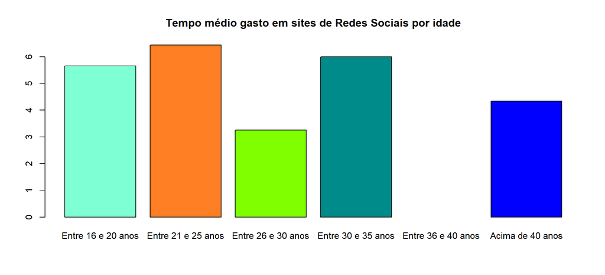

Assim como a sociedade, as metodologias de ensino buscam se aperfeiçoar e adaptar-se com o passar do tempo e levando em consideração o grande uso das redes sociais pelos alunos, seria uma estratégia interessante por parte dos professores, utiliza-las como ferramenta de ensino.

### O uso das Redes Sociais como ferramenta de ensino.

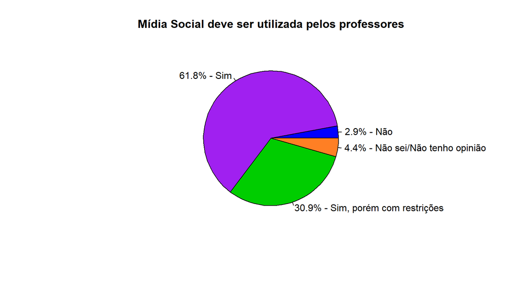

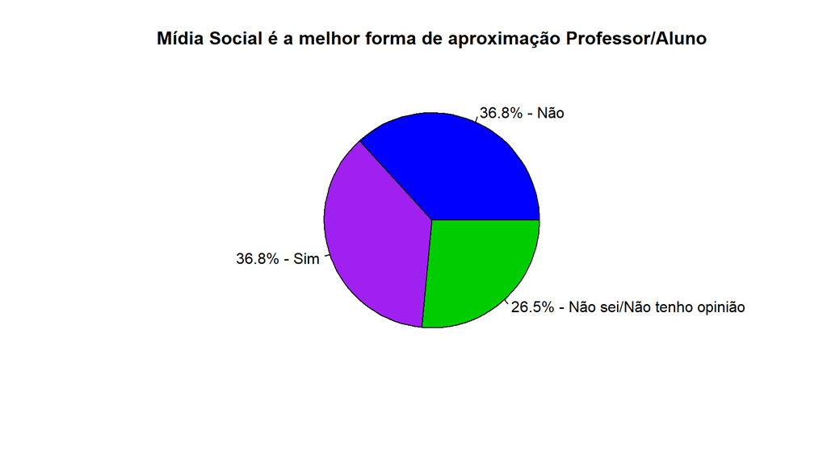

Com a facilidade do compartilhamento de dados e comunicação fornecida, a utilização das Redes Sociais traria muitos benefícios. Segundo Carvalho Jr., dentro das possibilidades de redes sociais como o Facebook, por exemplo, o professor pode:

“- Postar fotos, textos e reportagens de determinado tema desenvolvido em aula, como a realidade profissional de algumas modalidades esportivas visando sempre ao debate e aprofundamento do estudo; - Convidar pessoas (alunos, professores, profissionais renomados) de fora da instituição para participar do debate e estudo, promovendo intercâmbio entre os estudantes e enriquecendo a aprendizagem; - Utilizar o perfil de cada aluno para conhecer sua realidade, sua história de vida, o que daria ao professor subsídios para promover uma aprendizagem significativa; - Organizar os fóruns (tópicos) do grupo criado, facilitando a interação, promovendo debates e discussões que enriquecem a formação do aluno e desenvolvendo todas as dimensões do conteúdo/conhecimento com os alunos; - Eleger alunos representantes de turma que poderiam ser moderadores do grupo, ajudando na eliminação de dúvidas, aprofundamento do estudo, debates, reflexões etc.; - Divulgar eventos esportivos e culturais, dicas e orientações de estudo, de atividades físicas e de atividades de lazer.” (CARVALHO JR, A. 2014)

Além dos benefícios acima citados, 58,8% dos entrevistados acreditam que o uso das mídias sociais podem melhorar os resultados dos discentes, contra uma rejeição de apenas 14,7%. 26,5% dos entrevistados não sabem ou não puderam opinar sobre o assunto, o que dá embasamento para que professores possam testar em sala de aula a utilização das redes sociais. Levando em conta que haverá aceitação da utilização da rede social em sala de aula. O próximo gráfico ilustra os dados.

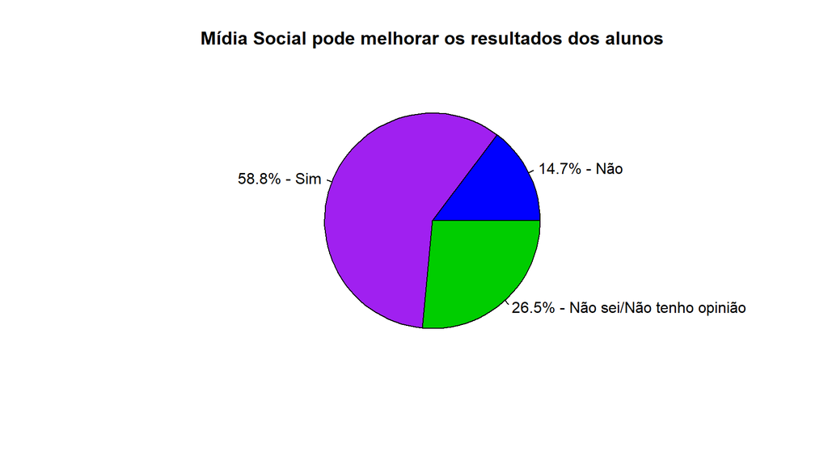

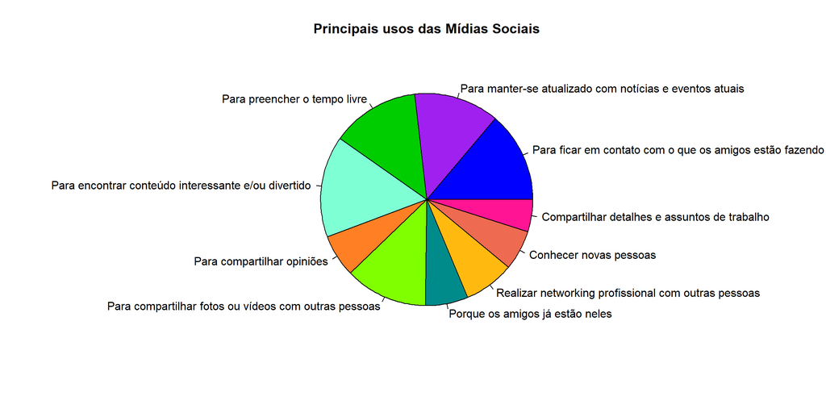

### O revés das redes sociais como ferramenta.

Por mais que as redes sociais possam parecer atraentes e tenham uma grande adesão, é importante levar em consideração as dificuldades que elas apresentam em relação ao aprendizado. O maior desafio é o de transformar a presença dos aparelhos tecnológicos em aproveitamento real. Quando questionados sobre as principais dificuldades do uso das mídias sociais em um ambiente educacional, a maior escolha por parte de nossa amostra foi em sua grande maioria a opção “distração”“, como é possível ver no próximo gráfico.

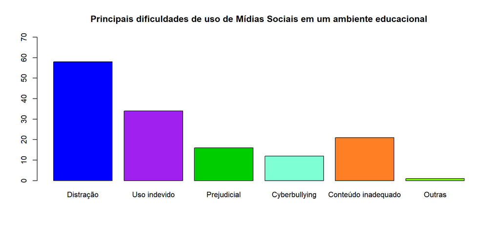

Com os discentes constantemente conectados e a grande quantidade de opções de entretenimento disponíveis, é fácil acabar se distraindo, e esse é um problema para todas as gerações. Em uma tentativa de resolver o problema, a Lei Distrital nº 4.131/2008 proíbe a utilização de aparelhos celulares na sala de aula dos colégios no Distrito Federal. (MEIRA, S. 2016)

Cabe salientar que um professor sempre poderá enriquecer sua aula utilizando-se de ferramentas de interação como as redes sociais. Para isso é necessário que o professor tenha conhecimento de tais ferramentas, além de um certo controle das ações que os alunos realizam através das mesmas. Não é raro encontrar casos onde instituições introduzem a tecnologia como medida de marketing, tentando passar uma imagem de modernidade, mas que muitas vezes não se sai tão bem quanto prometido.

### Caso as redes sociais se tornem realmente uma ferramenta de apoio para os professores, por onde eles devem começar

#### Por onde começar?

As redes sociais são ambientes virtuais informais, sendo grande parte delas de acesso irrestrito. Muitas instituições de ensino, principalmente na modalidade Educação a Distância (EaD), oferecem suas próprias redes, plataformas virtuais abertas para seus alunos e professores com grupos de discussões, chats e troca de arquivos. (CARVALHO JR, A. 2014)

Abaixo podemos ver as redes sociais mais utilizadas pela amostra, onde aqueles professores interessados em utilizar uma rede social como ferramenta, poderiam tentar uma aproximação ou atividade que envolvesse as mesmas.

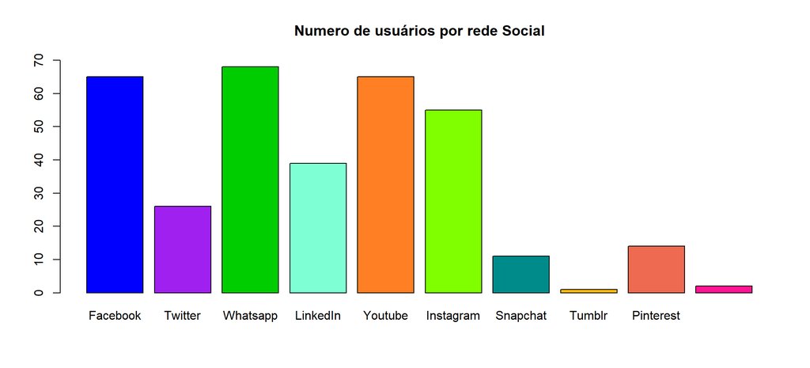

### O tempo gasto em uso de mídias sociais influencia na crença de que o seu uso pode melhorar o resultado dos alunos?

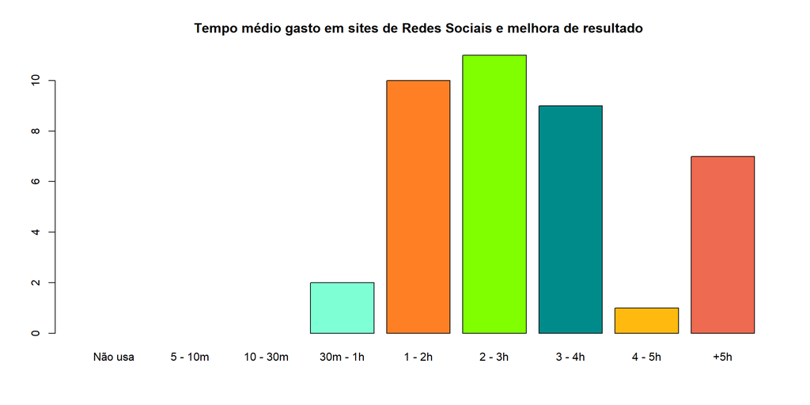

## Conclusão

Dado o que foi apresentado neste relatório podemos concluir que, muitas instituições estão começando a utilizar as redes sociais para auxiliar no ensino e tentar uma melhora no rendimento dos alunos. Segundo o que foi exposto neste relatório alunos acham que esta é uma técnica interessante e que pode sim melhorar o aproveitamento deles em sala de aula, como a melhora do aprendizado, praticidade, facilidade no acesso às informações, entre outras características. Ainda assim, professores têm certo preconceito com a utilização das redes sociais como ferramentas de auxílio, pois ainda é muito complicado de controlar, em sala de aula, o que os alunos estão fazendo em seus celulares ou computadores. Além disso, é sempre bom lembrar que por mais que as Redes ou Mídias Sociais possam auxiliar no aprendizado, as mesmas não substituem um professor de verdade, e sem o auxílio do mesmo, qualquer técnica de introdução destas ferramentas no processo de ensino se torna inútil.

## Referências Bibliográficas

CARVALHO JR., Arlindo. **As redes sociais como ferramentas didáticas virtuais de interação e ensino**. Disponível em: http://educacaopublica.cederj.edu.br/revista/artigos/as-redes-sociais-como-ferramentas-didaticas-virtuais-de-interacao-e-ensino. Acesso em: 26 de nov. de 2018 MEIRA, Samara. **REDES SOCIAIS COMO FERRAMENTA DE ENSINO DOS FENÔMENOS ÓPTICOS**. Disponível em: http://mnpef.fis.unb.br/download/dissertacao_samara.pdf. Acesso em: 26 de nov. de 2018